# UNBDH Youth Track

**HRS Tech:**

1. Ahmad Afif Mauludi
2. Ulan Surjayanto
3. Razis Aji Saputro
4. Bayu Ade Krisna Setiawan

### Themes:

The rise of food and energy prices affecting vicious cycles of poverty, hunger, and inequalities

```python
#Import library

# general
import numpy as np
import pandas as pd
import warnings
warnings.filterwarnings('ignore')

# visualization
import matplotlib.pyplot as plt
import seaborn as sns; sns.set()
import matplotlib.style as style
import matplotlib.ticker as mtick

# datetime
import datetime as dt
from datetime import date

# standardization
from sklearn.preprocessing import StandardScaler

# clustering
from sklearn.cluster import KMeans
from sklearn.metrics import silhouette_score
from sklearn.decomposition import PCA
```

```python
df = pd.read_excel('dataset_combine_finalv2.xlsx')
```

```python
df.head()
```

|  | country | iso_code | region | sub-region | intermediate-region | year | population | EP.PMP.DESL.CD | NY.GDP.COAL.RT.ZS | NY.GDP.PETR.RT.ZS | ... | solar_share_elec | solar_share_energy | wind_cons_change_pct | wind_cons_change_twh | wind_consumption | wind_elec_per_capita | wind_electricity | wind_energy_per_capita | wind_share_elec | wind_share_energy |
| --- | --- | --- | --- | --- | --- | --- | --- | --- | --- | --- | --- | --- | --- | --- | --- | --- | --- | --- | --- | --- | --- |
| 0 | Afghanistan | AFG | Asia | Southern Asia | 0 | 1900 | 4832414.0 | NaN | NaN | NaN | ... | NaN | NaN | NaN | NaN | NaN | NaN | NaN | NaN | NaN | NaN |
| 1 | Afghanistan | AFG | Asia | Southern Asia | 0 | 1901 | 4879685.0 | NaN | NaN | NaN | ... | NaN | NaN | NaN | NaN | NaN | NaN | NaN | NaN | NaN | NaN |
| 2 | Afghanistan | AFG | Asia | Southern Asia | 0 | 1902 | 4935122.0 | NaN | NaN | NaN | ... | NaN | NaN | NaN | NaN | NaN | NaN | NaN | NaN | NaN | NaN |
| 3 | Afghanistan | AFG | Asia | Southern Asia | 0 | 1903 | 4998861.0 | NaN | NaN | NaN | ... | NaN | NaN | NaN | NaN | NaN | NaN | NaN | NaN | NaN | NaN |
| 4 | Afghanistan | AFG | Asia | Southern Asia | 0 | 1904 | 5063419.0 | NaN | NaN | NaN | ... | NaN | NaN | NaN | NaN | NaN | NaN | NaN | NaN | NaN | NaN |

5 rows × 153 columns

```python
df.sample()
```

|  | country | iso_code | region | sub-region | intermediate-region | year | population | EP.PMP.DESL.CD | NY.GDP.COAL.RT.ZS | NY.GDP.PETR.RT.ZS | ... | solar_share_elec | solar_share_energy | wind_cons_change_pct | wind_cons_change_twh | wind_consumption | wind_elec_per_capita | wind_electricity | wind_energy_per_capita | wind_share_elec | wind_share_energy |
| --- | --- | --- | --- | --- | --- | --- | --- | --- | --- | --- | --- | --- | --- | --- | --- | --- | --- | --- | --- | --- | --- |
| 15896 | Venezuela | VEN | Americas | Latin America and the Caribbean | South America | 1982 | 16017570.0 | NaN | NaN | NaN | ... | NaN | 0.0 | NaN | 0.0 | 0.0 | 0.0 | 0.0 | 0.0 | NaN | 0.0 |

1 rows × 153 columns

```python
df.info()
```

```
<class 'pandas.core.frame.DataFrame'>
RangeIndex: 16476 entries, 0 to 16475
Columns: 153 entries, country to wind_share_energy
dtypes: float64(147), int64(1), object(5)
memory usage: 19.2+ MB
```

```python
var = """country
region
year
population
gdp
SI.POV.NAHC
SI.POV.GAPS
SI.POV.LMIC.GP
SI.POV.UMIC
SI.POV.MDIM
SI.POV.MDIM.MA
SI.POV.MDIM.FE
SN.ITK.SVFI.ZS
SN.ITK.MSFI.ZS
SN.ITK.DEFC.ZS
SI.POV.GINI
biofuel_cons_per_capita
coal_cons_per_capita
energy_per_capita
fossil_energy_per_capita
gas_energy_per_capita
hydro_energy_per_capita
low_carbon_energy_per_capita
nuclear_energy_per_capita
oil_energy_per_capita
other_renewables_energy_per_capita
renewables_energy_per_capita
solar_energy_per_capita
wind_energy_per_capita
EP.PMP.DESL.CD
NY.COAL.RT.ZS
NY.PETR.RT.ZS
NY.TOTL.RT.ZS""".split('\n')

df5 = df[var]
```

```python
df5
```

|  | country | region | year | population | gdp | SI.POV.NAHC | SI.POV.GAPS | SI.POV.LMIC.GP | SI.POV.UMIC | SI.POV.MDIM | ... | nuclear_energy_per_capita | oil_energy_per_capita | other_renewables_energy_per_capita | renewables_energy_per_capita | solar_energy_per_capita | wind_energy_per_capita | EP.PMP.DESL.CD | NY.COAL.RT.ZS | NY.PETR.RT.ZS | NY.TOTL.RT.ZS |
| --- | --- | --- | --- | --- | --- | --- | --- | --- | --- | --- | --- | --- | --- | --- | --- | --- | --- | --- | --- | --- | --- |
| 0 | Afghanistan | Asia | 1900 | 4832414.0 | NaN | NaN | NaN | NaN | NaN | NaN | ... | NaN | NaN | NaN | NaN | NaN | NaN | NaN | NaN | NaN | NaN |
| 1 | Afghanistan | Asia | 1901 | 4879685.0 | NaN | NaN | NaN | NaN | NaN | NaN | ... | NaN | NaN | NaN | NaN | NaN | NaN | NaN | NaN | NaN | NaN |
| 2 | Afghanistan | Asia | 1902 | 4935122.0 | NaN | NaN | NaN | NaN | NaN | NaN | ... | NaN | NaN | NaN | NaN | NaN | NaN | NaN | NaN | NaN | NaN |
| 3 | Afghanistan | Asia | 1903 | 4998861.0 | NaN | NaN | NaN | NaN | NaN | NaN | ... | NaN | NaN | NaN | NaN | NaN | NaN | NaN | NaN | NaN | NaN |
| 4 | Afghanistan | Asia | 1904 | 5063419.0 | NaN | NaN | NaN | NaN | NaN | NaN | ... | NaN | NaN | NaN | NaN | NaN | NaN | NaN | NaN | NaN | NaN |
| ... | ... | ... | ... | ... | ... | ... | ... | ... | ... | ... | ... | ... | ... | ... | ... | ... | ... | ... | ... | ... | ... |
| 16471 | Zimbabwe | Africa | 2017 | 14236599.0 | 2.194784e+10 | 30.4 | 9.4 | 25.9 | 84.1 | NaN | ... | NaN | NaN | NaN | NaN | NaN | NaN | NaN | 1.293668e+10 | 0.0 | 1.325230e+11 |
| 16472 | Zimbabwe | Africa | 2018 | 14438812.0 | 2.271535e+10 | NaN | NaN | NaN | NaN | NaN | ... | NaN | NaN | NaN | NaN | NaN | NaN | NaN | 1.732246e+10 | 0.0 | 1.382246e+11 |
| 16473 | Zimbabwe | Africa | 2019 | 14645473.0 | NaN | 38.3 | 13.5 | 29.9 | 85.0 | NaN | ... | NaN | NaN | NaN | NaN | NaN | NaN | NaN | 0.000000e+00 | 0.0 | 0.000000e+00 |
| 16474 | Zimbabwe | Africa | 2020 | 14862927.0 | NaN | NaN | NaN | NaN | NaN | NaN | ... | NaN | NaN | NaN | NaN | NaN | NaN | NaN | 0.000000e+00 | 0.0 | 0.000000e+00 |
| 16475 | Zimbabwe | Africa | 2021 | 15092171.0 | NaN | NaN | NaN | NaN | NaN | NaN | ... | NaN | NaN | NaN | NaN | NaN | NaN | NaN | NaN | NaN | NaN |

16476 rows × 33 columns

```python
df5.info()
```

```
<class 'pandas.core.frame.DataFrame'>
RangeIndex: 16476 entries, 0 to 16475
Data columns (total 33 columns):
 #   Column                              Non-Null Count  Dtype
---  ------                              --------------  -----
 0   country                             16476 non-null  object
 1   region                              16251 non-null  object
 2   year                                16476 non-null  int64
 3   population                          16371 non-null  float64
 4   gdp                                 11004 non-null  float64
 5   SI.POV.NAHC                         960 non-null    float64
 6   SI.POV.GAPS                         1668 non-null   float64
 7   SI.POV.LMIC.GP                      1668 non-null   float64
 8   SI.POV.UMIC                         1667 non-null   float64
 9   SI.POV.MDIM                         431 non-null    float64
```

[output cut: 25 more lines]

```python
df5.describe().T
```

|  | count | mean | std | min | 25% | 50% | 75% | max |
| --- | --- | --- | --- | --- | --- | --- | --- | --- |
| year | 16476.0 | 1.972500e+03 | 3.521550e+01 | 1.900000e+03 | 1.943000e+03 | 1.983000e+03 | 2.002000e+03 | 2.021000e+03 |
| population | 16371.0 | 2.680931e+07 | 1.013100e+08 | 1.606000e+03 | 1.295024e+06 | 5.800524e+06 | 1.700528e+07 | 1.444216e+09 |
| gdp | 11004.0 | 2.882041e+11 | 1.069311e+12 | 1.642060e+08 | 1.349916e+10 | 4.099142e+10 | 1.661650e+11 | 1.815162e+13 |
| SI.POV.NAHC | 960.0 | 2.638177e+01 | 1.581105e+01 | 0.000000e+00 | 1.540000e+01 | 2.160000e+01 | 3.452500e+01 | 9.600000e+01 |
| SI.POV.GAPS | 1668.0 | 3.999400e+00 | 7.906833e+00 | 0.000000e+00 | 1.000000e-01 | 6.000000e-01 | 3.800000e+00 | 5.660000e+01 |
| SI.POV.LMIC.GP | 1668.0 | 8.569365e+00 | 1.356707e+01 | 0.000000e+00 | 3.000000e-01 | 1.800000e+00 | 1.140000e+01 | 7.170000e+01 |
| SI.POV.UMIC | 1667.0 | 3.386077e+01 | 3.363052e+01 | 0.000000e+00 | 1.700000e+00 | 2.350000e+01 | 6.145000e+01 | 1.000000e+02 |
| SI.POV.MDIM | 431.0 | 2.667811e+01 | 1.074678e+01 | 2.370000e+00 | 1.830000e+01 | 2.480000e+01 | 3.255000e+01 | 7.420000e+01 |
| SI.POV.MDIM.MA | 357.0 | 2.488014e+01 | 9.399924e+00 | 2.263670e+00 | 1.750000e+01 | 2.250000e+01 | 2.990000e+01 | 6.264000e+01 |
| SI.POV.MDIM.FE | 357.0 | 2.625540e+01 | 9.228789e+00 | 2.473420e+00 | 1.930000e+01 | 2.440000e+01 | 3.150000e+01 | 6.065000e+01 |
| SN.ITK.SVFI.ZS | 665.0 | 9.696391e+00 | 1.188152e+01 | 0.000000e+00 | 1.500000e+00 | 4.900000e+00 | 1.400000e+01 | 6.540000e+01 |
| SN.ITK.MSFI.ZS | 671.0 | 2.814098e+01 | 2.260487e+01 | 2.000000e+00 | 8.900000e+00 | 2.100000e+01 | 4.340000e+01 | 8.670000e+01 |
| SN.ITK.DEFC.ZS | 2816.0 | 1.049002e+01 | 1.118630e+01 | 2.500000e+00 | 2.500000e+00 | 6.100000e+00 | 1.432500e+01 | 7.090000e+01 |
| SI.POV.GINI | 1663.0 | 3.845298e+01 | 9.228049e+00 | 2.070000e+01 | 3.150000e+01 | 3.610000e+01 | 4.490000e+01 | 6.580000e+01 |
| biofuel_cons_per_capita | 838.0 | 1.727147e+02 | 2.840871e+02 | 0.000000e+00 | 0.000000e+00 | 1.898200e+01 | 2.634190e+02 | 1.800258e+03 |
| coal_cons_per_capita | 4196.0 | 5.802764e+03 | 8.984715e+03 | 0.000000e+00 | 2.180865e+02 | 2.214950e+03 | 8.028419e+03 | 9.606304e+04 |
| energy_per_capita | 9521.0 | 2.619289e+04 | 3.770486e+04 | 0.000000e+00 | 2.969389e+03 | 1.332103e+04 | 3.602846e+04 | 6.518183e+05 |
| fossil_energy_per_capita | 4193.0 | 3.277921e+04 | 3.472323e+04 | 1.558070e+02 | 1.130402e+04 | 2.551277e+04 | 4.032868e+04 | 3.087042e+05 |
| gas_energy_per_capita | 4219.0 | 1.050400e+04 | 2.333601e+04 | 0.000000e+00 | 4.377430e+02 | 4.246422e+03 | 1.047437e+04 | 2.786258e+05 |
| hydro_energy_per_capita | 4215.0 | 3.945000e+03 | 1.183267e+04 | 0.000000e+00 | 7.955550e+01 | 5.782490e+02 | 2.217377e+03 | 1.123776e+05 |
| low_carbon_energy_per_capita | 4215.0 | 6.123222e+03 | 1.443177e+04 | 0.000000e+00 | 2.036985e+02 | 1.252909e+03 | 5.379003e+03 | 1.538834e+05 |
| nuclear_energy_per_capita | 4058.0 | 1.546590e+03 | 3.559373e+03 | 0.000000e+00 | 0.000000e+00 | 0.000000e+00 | 5.965548e+02 | 2.525298e+04 |
| oil_energy_per_capita | 4222.0 | 1.657494e+04 | 1.721647e+04 | 1.241430e+02 | 5.322733e+03 | 1.222450e+04 | 2.225224e+04 | 1.513602e+05 |
| other_renewables_energy_per_capita | 4172.0 | 4.406278e+02 | 2.592593e+03 | 0.000000e+00 | 0.000000e+00 | 8.194500e+00 | 1.827650e+02 | 4.531452e+04 |
| renewables_energy_per_capita | 4215.0 | 4.634868e+03 | 1.359040e+04 | 0.000000e+00 | 1.668300e+02 | 7.739260e+02 | 2.911323e+03 | 1.538834e+05 |
| solar_energy_per_capita | 4172.0 | 4.614549e+01 | 1.858606e+02 | 0.000000e+00 | 0.000000e+00 | 0.000000e+00 | 6.580000e-01 | 3.165171e+03 |
| wind_energy_per_capita | 4172.0 | 1.764750e+02 | 6.510687e+02 | 0.000000e+00 | 0.000000e+00 | 0.000000e+00 | 7.631000e+00 | 7.404413e+03 |
| EP.PMP.DESL.CD | 1582.0 | 8.009697e-01 | 4.603955e-01 | 1.000000e-02 | 4.100000e-01 | 7.550000e-01 | 1.110000e+00 | 3.000000e+00 |
| NY.COAL.RT.ZS | 6910.0 | 1.389545e+11 | 1.346063e+12 | 0.000000e+00 | 0.000000e+00 | 0.000000e+00 | 8.417389e+08 | 5.352508e+13 |
| NY.PETR.RT.ZS | 7054.0 | 6.983648e+11 | 3.066379e+12 | 0.000000e+00 | 0.000000e+00 | 0.000000e+00 | 9.085413e+10 | 6.959518e+13 |
| NY.TOTL.RT.ZS | 7145.0 | 1.149588e+12 | 4.489392e+12 | 0.000000e+00 | 1.573867e+09 | 6.068511e+10 | 4.024067e+11 | 1.049810e+14 |

```python
df5.describe(include='O').T
```

|  | count | unique | top | freq |
| --- | --- | --- | --- | --- |
| country | 16476 | 221 | Zimbabwe | 122 |
| region | 16251 | 6 | Asia | 4401 |

```python
cols = df5.columns.drop(['year','population','country','region'])
```

```python
df5[cols] = df5[cols].apply(pd.to_numeric, errors='coerce')
```

```python
df5['year'] = pd.to_datetime(df.year, format='%Y')
```

```python
df5.info()
```

```
<class 'pandas.core.frame.DataFrame'>
RangeIndex: 16476 entries, 0 to 16475
Data columns (total 33 columns):
 #   Column                              Non-Null Count  Dtype
---  ------                              --------------  -----
 0   country                             16476 non-null  object
 1   region                              16251 non-null  object
 2   year                                16476 non-null  datetime64[ns]
 3   population                          16371 non-null  float64
 4   gdp                                 11004 non-null  float64
 5   SI.POV.NAHC                         960 non-null    float64
 6   SI.POV.GAPS                         1668 non-null   float64
 7   SI.POV.LMIC.GP                      1668 non-null   float64
 8   SI.POV.UMIC                         1667 non-null   float64
 9   SI.POV.MDIM                         431 non-null    float64
```

[output cut: 25 more lines]

```python
df5.describe().T
```

|  | count | mean | std | min | 25% | 50% | 75% | max |
| --- | --- | --- | --- | --- | --- | --- | --- | --- |
| population | 16371.0 | 2.680931e+07 | 1.013100e+08 | 1.606000e+03 | 1.295024e+06 | 5.800524e+06 | 1.700528e+07 | 1.444216e+09 |
| gdp | 11004.0 | 2.882041e+11 | 1.069311e+12 | 1.642060e+08 | 1.349916e+10 | 4.099142e+10 | 1.661650e+11 | 1.815162e+13 |
| SI.POV.NAHC | 960.0 | 2.638177e+01 | 1.581105e+01 | 0.000000e+00 | 1.540000e+01 | 2.160000e+01 | 3.452500e+01 | 9.600000e+01 |
| SI.POV.GAPS | 1668.0 | 3.999400e+00 | 7.906833e+00 | 0.000000e+00 | 1.000000e-01 | 6.000000e-01 | 3.800000e+00 | 5.660000e+01 |
| SI.POV.LMIC.GP | 1668.0 | 8.569365e+00 | 1.356707e+01 | 0.000000e+00 | 3.000000e-01 | 1.800000e+00 | 1.140000e+01 | 7.170000e+01 |
| SI.POV.UMIC | 1667.0 | 3.386077e+01 | 3.363052e+01 | 0.000000e+00 | 1.700000e+00 | 2.350000e+01 | 6.145000e+01 | 1.000000e+02 |
| SI.POV.MDIM | 431.0 | 2.667811e+01 | 1.074678e+01 | 2.370000e+00 | 1.830000e+01 | 2.480000e+01 | 3.255000e+01 | 7.420000e+01 |
| SI.POV.MDIM.MA | 357.0 | 2.488014e+01 | 9.399924e+00 | 2.263670e+00 | 1.750000e+01 | 2.250000e+01 | 2.990000e+01 | 6.264000e+01 |
| SI.POV.MDIM.FE | 357.0 | 2.625540e+01 | 9.228789e+00 | 2.473420e+00 | 1.930000e+01 | 2.440000e+01 | 3.150000e+01 | 6.065000e+01 |
| SN.ITK.SVFI.ZS | 665.0 | 9.696391e+00 | 1.188152e+01 | 0.000000e+00 | 1.500000e+00 | 4.900000e+00 | 1.400000e+01 | 6.540000e+01 |
| SN.ITK.MSFI.ZS | 671.0 | 2.814098e+01 | 2.260487e+01 | 2.000000e+00 | 8.900000e+00 | 2.100000e+01 | 4.340000e+01 | 8.670000e+01 |
| SN.ITK.DEFC.ZS | 2816.0 | 1.049002e+01 | 1.118630e+01 | 2.500000e+00 | 2.500000e+00 | 6.100000e+00 | 1.432500e+01 | 7.090000e+01 |
| SI.POV.GINI | 1663.0 | 3.845298e+01 | 9.228049e+00 | 2.070000e+01 | 3.150000e+01 | 3.610000e+01 | 4.490000e+01 | 6.580000e+01 |
| biofuel_cons_per_capita | 838.0 | 1.727147e+02 | 2.840871e+02 | 0.000000e+00 | 0.000000e+00 | 1.898200e+01 | 2.634190e+02 | 1.800258e+03 |
| coal_cons_per_capita | 4196.0 | 5.802764e+03 | 8.984715e+03 | 0.000000e+00 | 2.180865e+02 | 2.214950e+03 | 8.028419e+03 | 9.606304e+04 |
| energy_per_capita | 9521.0 | 2.619289e+04 | 3.770486e+04 | 0.000000e+00 | 2.969389e+03 | 1.332103e+04 | 3.602846e+04 | 6.518183e+05 |
| fossil_energy_per_capita | 4193.0 | 3.277921e+04 | 3.472323e+04 | 1.558070e+02 | 1.130402e+04 | 2.551277e+04 | 4.032868e+04 | 3.087042e+05 |
| gas_energy_per_capita | 4219.0 | 1.050400e+04 | 2.333601e+04 | 0.000000e+00 | 4.377430e+02 | 4.246422e+03 | 1.047437e+04 | 2.786258e+05 |
| hydro_energy_per_capita | 4215.0 | 3.945000e+03 | 1.183267e+04 | 0.000000e+00 | 7.955550e+01 | 5.782490e+02 | 2.217377e+03 | 1.123776e+05 |
| low_carbon_energy_per_capita | 4215.0 | 6.123222e+03 | 1.443177e+04 | 0.000000e+00 | 2.036985e+02 | 1.252909e+03 | 5.379003e+03 | 1.538834e+05 |
| nuclear_energy_per_capita | 4058.0 | 1.546590e+03 | 3.559373e+03 | 0.000000e+00 | 0.000000e+00 | 0.000000e+00 | 5.965548e+02 | 2.525298e+04 |
| oil_energy_per_capita | 4222.0 | 1.657494e+04 | 1.721647e+04 | 1.241430e+02 | 5.322733e+03 | 1.222450e+04 | 2.225224e+04 | 1.513602e+05 |
| other_renewables_energy_per_capita | 4172.0 | 4.406278e+02 | 2.592593e+03 | 0.000000e+00 | 0.000000e+00 | 8.194500e+00 | 1.827650e+02 | 4.531452e+04 |
| renewables_energy_per_capita | 4215.0 | 4.634868e+03 | 1.359040e+04 | 0.000000e+00 | 1.668300e+02 | 7.739260e+02 | 2.911323e+03 | 1.538834e+05 |
| solar_energy_per_capita | 4172.0 | 4.614549e+01 | 1.858606e+02 | 0.000000e+00 | 0.000000e+00 | 0.000000e+00 | 6.580000e-01 | 3.165171e+03 |
| wind_energy_per_capita | 4172.0 | 1.764750e+02 | 6.510687e+02 | 0.000000e+00 | 0.000000e+00 | 0.000000e+00 | 7.631000e+00 | 7.404413e+03 |
| EP.PMP.DESL.CD | 1582.0 | 8.009697e-01 | 4.603955e-01 | 1.000000e-02 | 4.100000e-01 | 7.550000e-01 | 1.110000e+00 | 3.000000e+00 |
| NY.COAL.RT.ZS | 6910.0 | 1.389545e+11 | 1.346063e+12 | 0.000000e+00 | 0.000000e+00 | 0.000000e+00 | 8.417389e+08 | 5.352508e+13 |
| NY.PETR.RT.ZS | 7054.0 | 6.983648e+11 | 3.066379e+12 | 0.000000e+00 | 0.000000e+00 | 0.000000e+00 | 9.085413e+10 | 6.959518e+13 |
| NY.TOTL.RT.ZS | 7145.0 | 1.149588e+12 | 4.489392e+12 | 0.000000e+00 | 1.573867e+09 | 6.068511e+10 | 4.024067e+11 | 1.049810e+14 |

```python
df5.describe(include='O').T
```

|  | count | unique | top | freq |
| --- | --- | --- | --- | --- |
| country | 16476 | 221 | Zimbabwe | 122 |
| region | 16251 | 6 | Asia | 4401 |

```python
df5.describe(include='O').T
```

|  | count | unique | top | freq |
| --- | --- | --- | --- | --- |
| country | 16476 | 221 | Zimbabwe | 122 |
| region | 16251 | 6 | Asia | 4401 |

```python
df5.describe().T
```

|  | count | mean | std | min | 25% | 50% | 75% | max |
| --- | --- | --- | --- | --- | --- | --- | --- | --- |
| population | 16371.0 | 2.680931e+07 | 1.013100e+08 | 1.606000e+03 | 1.295024e+06 | 5.800524e+06 | 1.700528e+07 | 1.444216e+09 |
| gdp | 11004.0 | 2.882041e+11 | 1.069311e+12 | 1.642060e+08 | 1.349916e+10 | 4.099142e+10 | 1.661650e+11 | 1.815162e+13 |
| SI.POV.NAHC | 960.0 | 2.638177e+01 | 1.581105e+01 | 0.000000e+00 | 1.540000e+01 | 2.160000e+01 | 3.452500e+01 | 9.600000e+01 |
| SI.POV.GAPS | 1668.0 | 3.999400e+00 | 7.906833e+00 | 0.000000e+00 | 1.000000e-01 | 6.000000e-01 | 3.800000e+00 | 5.660000e+01 |
| SI.POV.LMIC.GP | 1668.0 | 8.569365e+00 | 1.356707e+01 | 0.000000e+00 | 3.000000e-01 | 1.800000e+00 | 1.140000e+01 | 7.170000e+01 |
| SI.POV.UMIC | 1667.0 | 3.386077e+01 | 3.363052e+01 | 0.000000e+00 | 1.700000e+00 | 2.350000e+01 | 6.145000e+01 | 1.000000e+02 |
| SI.POV.MDIM | 431.0 | 2.667811e+01 | 1.074678e+01 | 2.370000e+00 | 1.830000e+01 | 2.480000e+01 | 3.255000e+01 | 7.420000e+01 |
| SI.POV.MDIM.MA | 357.0 | 2.488014e+01 | 9.399924e+00 | 2.263670e+00 | 1.750000e+01 | 2.250000e+01 | 2.990000e+01 | 6.264000e+01 |
| SI.POV.MDIM.FE | 357.0 | 2.625540e+01 | 9.228789e+00 | 2.473420e+00 | 1.930000e+01 | 2.440000e+01 | 3.150000e+01 | 6.065000e+01 |
| SN.ITK.SVFI.ZS | 665.0 | 9.696391e+00 | 1.188152e+01 | 0.000000e+00 | 1.500000e+00 | 4.900000e+00 | 1.400000e+01 | 6.540000e+01 |
| SN.ITK.MSFI.ZS | 671.0 | 2.814098e+01 | 2.260487e+01 | 2.000000e+00 | 8.900000e+00 | 2.100000e+01 | 4.340000e+01 | 8.670000e+01 |
| SN.ITK.DEFC.ZS | 2816.0 | 1.049002e+01 | 1.118630e+01 | 2.500000e+00 | 2.500000e+00 | 6.100000e+00 | 1.432500e+01 | 7.090000e+01 |
| SI.POV.GINI | 1663.0 | 3.845298e+01 | 9.228049e+00 | 2.070000e+01 | 3.150000e+01 | 3.610000e+01 | 4.490000e+01 | 6.580000e+01 |
| biofuel_cons_per_capita | 838.0 | 1.727147e+02 | 2.840871e+02 | 0.000000e+00 | 0.000000e+00 | 1.898200e+01 | 2.634190e+02 | 1.800258e+03 |
| coal_cons_per_capita | 4196.0 | 5.802764e+03 | 8.984715e+03 | 0.000000e+00 | 2.180865e+02 | 2.214950e+03 | 8.028419e+03 | 9.606304e+04 |
| energy_per_capita | 9521.0 | 2.619289e+04 | 3.770486e+04 | 0.000000e+00 | 2.969389e+03 | 1.332103e+04 | 3.602846e+04 | 6.518183e+05 |
| fossil_energy_per_capita | 4193.0 | 3.277921e+04 | 3.472323e+04 | 1.558070e+02 | 1.130402e+04 | 2.551277e+04 | 4.032868e+04 | 3.087042e+05 |
| gas_energy_per_capita | 4219.0 | 1.050400e+04 | 2.333601e+04 | 0.000000e+00 | 4.377430e+02 | 4.246422e+03 | 1.047437e+04 | 2.786258e+05 |
| hydro_energy_per_capita | 4215.0 | 3.945000e+03 | 1.183267e+04 | 0.000000e+00 | 7.955550e+01 | 5.782490e+02 | 2.217377e+03 | 1.123776e+05 |
| low_carbon_energy_per_capita | 4215.0 | 6.123222e+03 | 1.443177e+04 | 0.000000e+00 | 2.036985e+02 | 1.252909e+03 | 5.379003e+03 | 1.538834e+05 |
| nuclear_energy_per_capita | 4058.0 | 1.546590e+03 | 3.559373e+03 | 0.000000e+00 | 0.000000e+00 | 0.000000e+00 | 5.965548e+02 | 2.525298e+04 |
| oil_energy_per_capita | 4222.0 | 1.657494e+04 | 1.721647e+04 | 1.241430e+02 | 5.322733e+03 | 1.222450e+04 | 2.225224e+04 | 1.513602e+05 |
| other_renewables_energy_per_capita | 4172.0 | 4.406278e+02 | 2.592593e+03 | 0.000000e+00 | 0.000000e+00 | 8.194500e+00 | 1.827650e+02 | 4.531452e+04 |
| renewables_energy_per_capita | 4215.0 | 4.634868e+03 | 1.359040e+04 | 0.000000e+00 | 1.668300e+02 | 7.739260e+02 | 2.911323e+03 | 1.538834e+05 |
| solar_energy_per_capita | 4172.0 | 4.614549e+01 | 1.858606e+02 | 0.000000e+00 | 0.000000e+00 | 0.000000e+00 | 6.580000e-01 | 3.165171e+03 |
| wind_energy_per_capita | 4172.0 | 1.764750e+02 | 6.510687e+02 | 0.000000e+00 | 0.000000e+00 | 0.000000e+00 | 7.631000e+00 | 7.404413e+03 |
| EP.PMP.DESL.CD | 1582.0 | 8.009697e-01 | 4.603955e-01 | 1.000000e-02 | 4.100000e-01 | 7.550000e-01 | 1.110000e+00 | 3.000000e+00 |
| NY.COAL.RT.ZS | 6910.0 | 1.389545e+11 | 1.346063e+12 | 0.000000e+00 | 0.000000e+00 | 0.000000e+00 | 8.417389e+08 | 5.352508e+13 |
| NY.PETR.RT.ZS | 7054.0 | 6.983648e+11 | 3.066379e+12 | 0.000000e+00 | 0.000000e+00 | 0.000000e+00 | 9.085413e+10 | 6.959518e+13 |
| NY.TOTL.RT.ZS | 7145.0 | 1.149588e+12 | 4.489392e+12 | 0.000000e+00 | 1.573867e+09 | 6.068511e+10 | 4.024067e+11 | 1.049810e+14 |

```python
def cat_num (df):
    for typ,col in zip(df.dtypes.values,df.dtypes.index):
        if typ == "object":
             cat_col.append(col)
        else:
            num_col.append(col);

def cat_count(df):
    cat_columns = df[cat_col]
    for col in cat_columns:
        print(f'value counts dari column {col}')
        print(df[col].value_counts())
        print('---'*10, '\n');
```

```python
cat_col=[]
num_col=[]

cat_num (df5)
```

```python
cat_col
```

```
['country', 'region']
```

```python
num_col
```

```
['year',
 'population',
 'gdp',
 'SI.POV.NAHC',
 'SI.POV.GAPS',
 'SI.POV.LMIC.GP',
 'SI.POV.UMIC',
 'SI.POV.MDIM',
 'SI.POV.MDIM.MA',
 'SI.POV.MDIM.FE',
 'SN.ITK.SVFI.ZS',
 'SN.ITK.MSFI.ZS',
 'SN.ITK.DEFC.ZS',
 'SI.POV.GINI',
 'biofuel_cons_per_capita',
 'coal_cons_per_capita',
 'energy_per_capita',
 'fossil_energy_per_capita',
 'gas_energy_per_capita',
 'hydro_energy_per_capita',
 'low_carbon_energy_per_capita',
 'nuclear_energy_per_capita',
 'oil_energy_per_capita',
 'other_renewables_energy_per_capita',
 'renewables_energy_per_capita',
 'solar_energy_per_capita',
 'wind_energy_per_capita',
 'EP.PMP.DESL.CD',
 'NY.COAL.RT.ZS',
 'NY.PETR.RT.ZS',
 'NY.TOTL.RT.ZS']
```

```python
num_col.remove('year')
```

```python
date_col = ['year']
```

```python
df5.info()
```

```
<class 'pandas.core.frame.DataFrame'>
RangeIndex: 16476 entries, 0 to 16475
Data columns (total 33 columns):
 #   Column                              Non-Null Count  Dtype
---  ------                              --------------  -----
 0   country                             16476 non-null  object
 1   region                              16251 non-null  object
 2   year                                16476 non-null  datetime64[ns]
 3   population                          16371 non-null  float64
 4   gdp                                 11004 non-null  float64
 5   SI.POV.NAHC                         960 non-null    float64
 6   SI.POV.GAPS                         1668 non-null   float64
 7   SI.POV.LMIC.GP                      1668 non-null   float64
 8   SI.POV.UMIC                         1667 non-null   float64
 9   SI.POV.MDIM                         431 non-null    float64
```

[output cut: 25 more lines]

```python
cat_count (df5)
```

```
value counts dari column country
Zimbabwe       122
Morocco        122
Ecuador        122
Myanmar        122
Netherlands    122
              ...
Eritrea         27
Palestine       24
Timor           18
Montenegro      17
South Sudan     10
Name: country, Length: 221, dtype: int64
------------------------------

value counts dari column region
Asia        4401
Africa      4139
Americas    3378
Europe      3355
Oceania      938
0             40
Name: region, dtype: int64
------------------------------
```

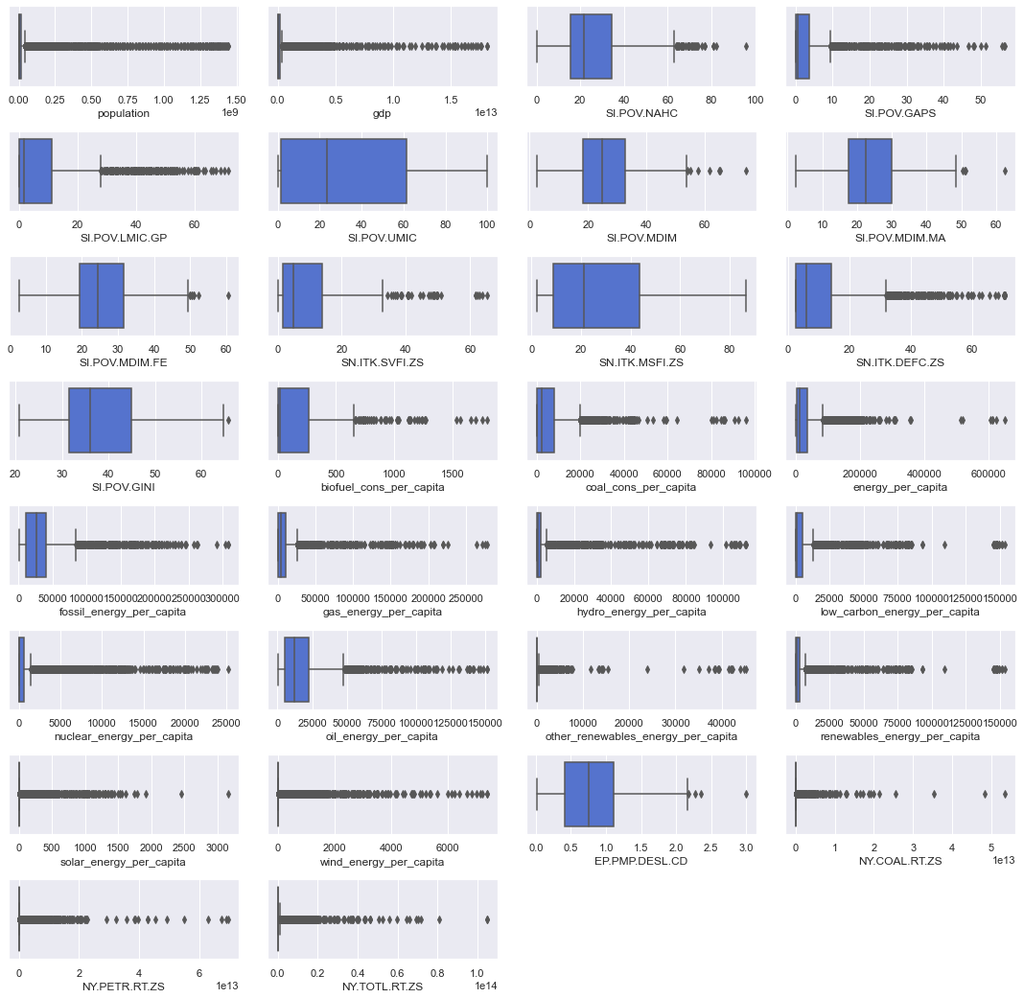

```python
plt.figure(figsize=(15,25))
for i in range(0, len(num_col)):
    plt.subplot(14, 4, i+1)
    sns.boxplot(x=df5[num_col[i]], color='royalblue')
    plt.xlabel(num_col[i])
    plt.tight_layout()
```

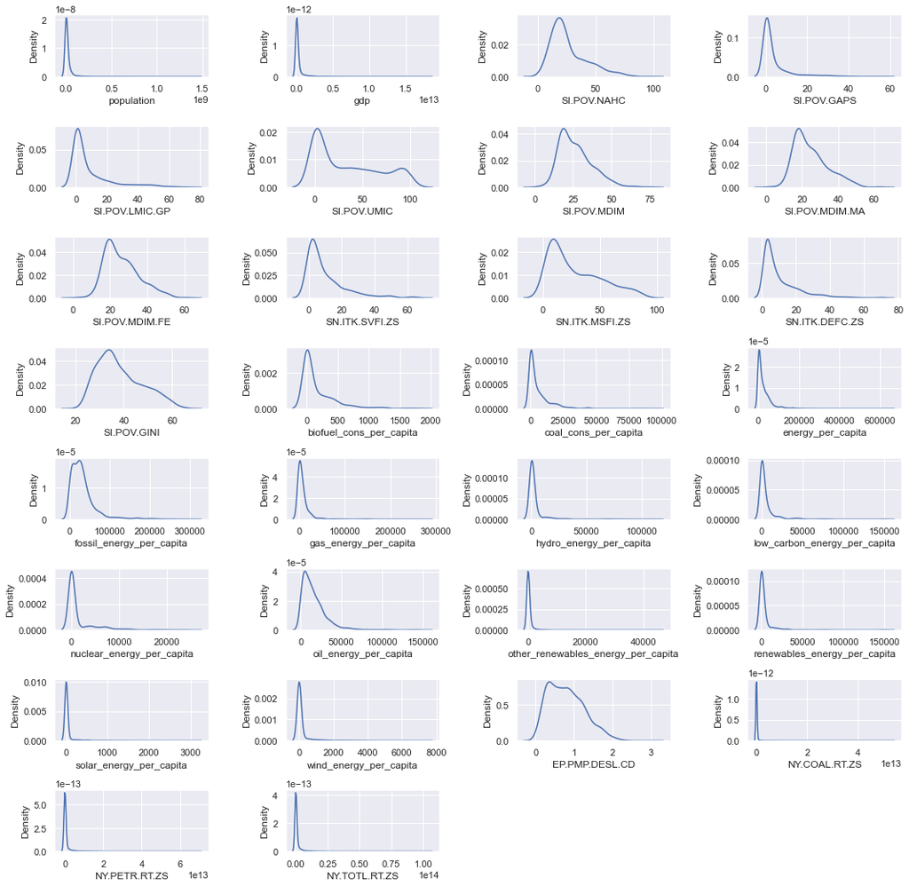

```python
plt.figure(figsize= (15, 25))
for i in range(len(num_col)):
    plt.subplot(14, 4, i+1)
    sns.kdeplot(x = df5[num_col[i]])
    plt.tight_layout()
```

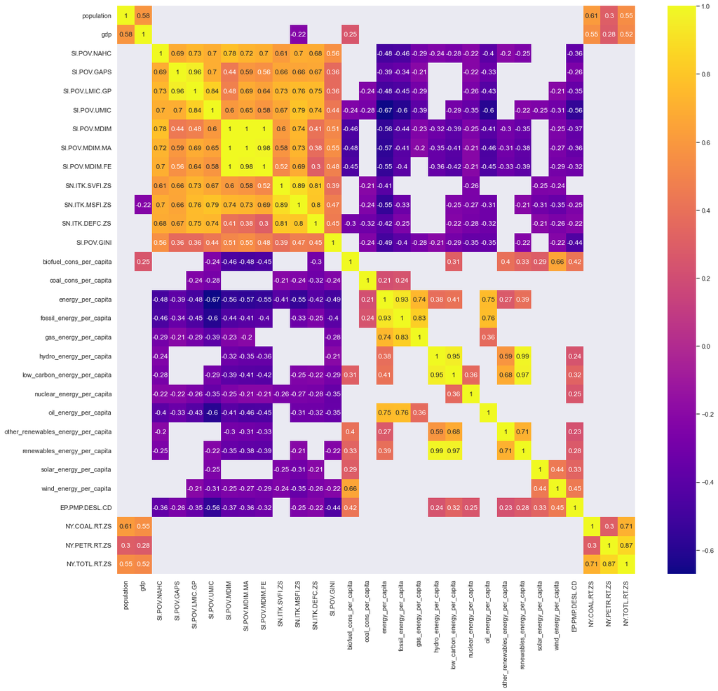

```python
var_corr = df5[num_col].corr()
fig = plt.figure(figsize = (20,18))
sns.heatmap(var_corr, cmap='plasma', annot=True, mask = (abs(var_corr) <= 0.2))
```

Observation:

- Both renewable and nonrenewable energy consumption tends to negatively correlate with Poverty, Hunger, and Inequalities
- The vicious cycle, including poverty, hunger, and inequalities tends to have a positive correlation with each other
- The rise of diesel fuel is negatively correlated with the vicious cycle and positively correlated with the rise of some renewable energy consumption.

## Clustering

Data Preparation

```python
def prep_data(x):
    import pandas as pd
    y = pd.read_excel(x)
    return y

df = prep_data('dataset_combine_finalv2.xlsx')
df.head()
```

|  | country | iso_code | region | sub-region | intermediate-region | year | population | EP.PMP.DESL.CD | NY.GDP.COAL.RT.ZS | NY.GDP.PETR.RT.ZS | ... | solar_share_elec | solar_share_energy | wind_cons_change_pct | wind_cons_change_twh | wind_consumption | wind_elec_per_capita | wind_electricity | wind_energy_per_capita | wind_share_elec | wind_share_energy |
| --- | --- | --- | --- | --- | --- | --- | --- | --- | --- | --- | --- | --- | --- | --- | --- | --- | --- | --- | --- | --- | --- |
| 0 | Afghanistan | AFG | Asia | Southern Asia | 0 | 1900 | 4832414.0 | NaN | NaN | NaN | ... | NaN | NaN | NaN | NaN | NaN | NaN | NaN | NaN | NaN | NaN |
| 1 | Afghanistan | AFG | Asia | Southern Asia | 0 | 1901 | 4879685.0 | NaN | NaN | NaN | ... | NaN | NaN | NaN | NaN | NaN | NaN | NaN | NaN | NaN | NaN |
| 2 | Afghanistan | AFG | Asia | Southern Asia | 0 | 1902 | 4935122.0 | NaN | NaN | NaN | ... | NaN | NaN | NaN | NaN | NaN | NaN | NaN | NaN | NaN | NaN |
| 3 | Afghanistan | AFG | Asia | Southern Asia | 0 | 1903 | 4998861.0 | NaN | NaN | NaN | ... | NaN | NaN | NaN | NaN | NaN | NaN | NaN | NaN | NaN | NaN |
| 4 | Afghanistan | AFG | Asia | Southern Asia | 0 | 1904 | 5063419.0 | NaN | NaN | NaN | ... | NaN | NaN | NaN | NaN | NaN | NaN | NaN | NaN | NaN | NaN |

5 rows × 153 columns

```python
var_clusters = """SI.POV.NAHC
SI.POV.GAPS
SI.POV.LMIC.GP
SI.POV.UMIC
SN.ITK.SVFI.ZS
SN.ITK.MSFI.ZS
SN.ITK.DEFC.ZS
SI.POV.GINI
EP.PMP.DESL.CD""".split('\n')

df_cluster = df[var_clusters]
df_cluster.head()
```

|  | SI.POV.NAHC | SI.POV.GAPS | SI.POV.LMIC.GP | SI.POV.UMIC | SN.ITK.SVFI.ZS | SN.ITK.MSFI.ZS | SN.ITK.DEFC.ZS | SI.POV.GINI | EP.PMP.DESL.CD |
| --- | --- | --- | --- | --- | --- | --- | --- | --- | --- |
| 0 | NaN | NaN | NaN | NaN | NaN | NaN | NaN | NaN | NaN |
| 1 | NaN | NaN | NaN | NaN | NaN | NaN | NaN | NaN | NaN |
| 2 | NaN | NaN | NaN | NaN | NaN | NaN | NaN | NaN | NaN |
| 3 | NaN | NaN | NaN | NaN | NaN | NaN | NaN | NaN | NaN |
| 4 | NaN | NaN | NaN | NaN | NaN | NaN | NaN | NaN | NaN |

```python
df_cluster.info()
```

```
<class 'pandas.core.frame.DataFrame'>
RangeIndex: 16476 entries, 0 to 16475
Data columns (total 9 columns):
 #   Column          Non-Null Count  Dtype
---  ------          --------------  -----
 0   SI.POV.NAHC     960 non-null    float64
 1   SI.POV.GAPS     1668 non-null   float64
 2   SI.POV.LMIC.GP  1668 non-null   float64
 3   SI.POV.UMIC     1667 non-null   float64
 4   SN.ITK.SVFI.ZS  665 non-null    float64
 5   SN.ITK.MSFI.ZS  671 non-null    float64
 6   SN.ITK.DEFC.ZS  2816 non-null   float64
 7   SI.POV.GINI     1663 non-null   float64
 8   EP.PMP.DESL.CD  1582 non-null   float64
dtypes: float64(9)
memory usage: 1.1 MB
```

```python
def standard(x):
    import pandas as pd
    from sklearn.preprocessing import StandardScaler
    scaler = StandardScaler()
    y = scaler.fit_transform(x)
    z = pd.DataFrame(y).fillna(0)
    return z

df_standar = standard(df_cluster)
df_standar.info()
```

```
<class 'pandas.core.frame.DataFrame'>
RangeIndex: 16476 entries, 0 to 16475
Data columns (total 9 columns):
 #   Column  Non-Null Count  Dtype
---  ------  --------------  -----
 0   0       16476 non-null  float64
 1   1       16476 non-null  float64
 2   2       16476 non-null  float64
 3   3       16476 non-null  float64
 4   4       16476 non-null  float64
 5   5       16476 non-null  float64
 6   6       16476 non-null  float64
 7   7       16476 non-null  float64
 8   8       16476 non-null  float64
dtypes: float64(9)
memory usage: 1.1 MB
```

Find Number of Optimal Cluster using Elbow Method

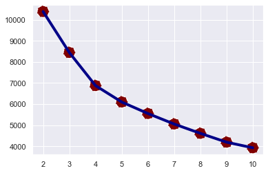

```python
inertia = []

from sklearn.cluster import KMeans
import matplotlib.pyplot as plt
import seaborn as sns
for i in range(2, 11):
    kmeans = KMeans(n_clusters=i, random_state=42)
    kmeans.fit(df_standar)
    inertia.append(kmeans.inertia_)



plt.figure(figsize=(6, 4))

sns.lineplot(x=range(2, 11), y=inertia, color='#000087', linewidth = 4)
sns.scatterplot(x=range(2, 11), y=inertia, s=300, color='#800000',  linestyle='--')
plt.show()
```

Find Number of Optimal Cluster using Silhoutte

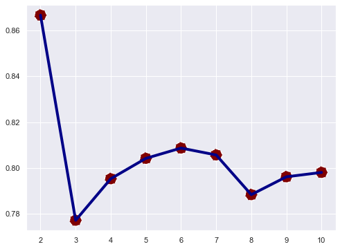

```python
from sklearn.metrics import silhouette_score
range_n_clusters = list(range(2,11))
arr_silhouette_score_euclidean = []
for i in range_n_clusters:
    kmeans = KMeans(n_clusters=i).fit(df_standar)
    preds = kmeans.predict(df_standar)

    score_euclidean = silhouette_score(df_standar, preds, metric='euclidean')
    arr_silhouette_score_euclidean.append(score_euclidean)

fig, ax = plt.subplots(figsize=(8, 6))
sns.lineplot(x=range(2,11), y=arr_silhouette_score_euclidean, color='#000087', linewidth = 4)
sns.scatterplot(x=range(2,11), y=arr_silhouette_score_euclidean, s=300, color='#800000',  linestyle='--')
plt.show()
```

Clustering using Kmeans (Cluster = 3)

```python
from sklearn.cluster import KMeans
kmeans = KMeans(n_clusters=3, random_state=42).fit(df_standar)
clusters = kmeans.labels_
df['clusters'] = clusters
df_cluster['clusters'] = clusters
df.head()
```

|  | country | iso_code | region | sub-region | intermediate-region | year | population | EP.PMP.DESL.CD | NY.GDP.COAL.RT.ZS | NY.GDP.PETR.RT.ZS | ... | solar_share_energy | wind_cons_change_pct | wind_cons_change_twh | wind_consumption | wind_elec_per_capita | wind_electricity | wind_energy_per_capita | wind_share_elec | wind_share_energy | clusters |
| --- | --- | --- | --- | --- | --- | --- | --- | --- | --- | --- | --- | --- | --- | --- | --- | --- | --- | --- | --- | --- | --- |
| 0 | Afghanistan | AFG | Asia | Southern Asia | 0 | 1900 | 4832414.0 | NaN | NaN | NaN | ... | NaN | NaN | NaN | NaN | NaN | NaN | NaN | NaN | NaN | 0 |
| 1 | Afghanistan | AFG | Asia | Southern Asia | 0 | 1901 | 4879685.0 | NaN | NaN | NaN | ... | NaN | NaN | NaN | NaN | NaN | NaN | NaN | NaN | NaN | 0 |
| 2 | Afghanistan | AFG | Asia | Southern Asia | 0 | 1902 | 4935122.0 | NaN | NaN | NaN | ... | NaN | NaN | NaN | NaN | NaN | NaN | NaN | NaN | NaN | 0 |
| 3 | Afghanistan | AFG | Asia | Southern Asia | 0 | 1903 | 4998861.0 | NaN | NaN | NaN | ... | NaN | NaN | NaN | NaN | NaN | NaN | NaN | NaN | NaN | 0 |
| 4 | Afghanistan | AFG | Asia | Southern Asia | 0 | 1904 | 5063419.0 | NaN | NaN | NaN | ... | NaN | NaN | NaN | NaN | NaN | NaN | NaN | NaN | NaN | 0 |

5 rows × 154 columns

Clusteri analysis using PCA

```python
from sklearn.decomposition import PCA
pca = PCA(n_components=2)

pca.fit(df_standar)
pcs = pca.transform(df_standar)

df_pca = pd.DataFrame(data = pcs, columns = ['PC 1', 'PC 2'])
df_pca.head()
```

|  | PC 1 | PC 2 |
| --- | --- | --- |
| 0 | -2.727399e-19 | -2.177297e-17 |
| 1 | -2.727399e-19 | -2.177297e-17 |
| 2 | -2.727399e-19 | -2.177297e-17 |
| 3 | -2.727399e-19 | -2.177297e-17 |
| 4 | -2.727399e-19 | -2.177297e-17 |

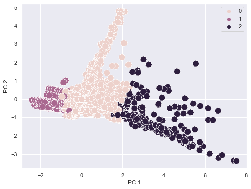

```python
fig, ax = plt.subplots(figsize=(8,6))

sns.scatterplot(
    x='PC 1', y='PC 2',
    hue=clusters,
    linestyle='--',
    data=df_pca,
    s=160,
    ax=ax
)


plt.show()
```

```python
df_cluster.groupby('clusters').median()
```

| clusters | SI.POV.NAHC | SI.POV.GAPS | SI.POV.LMIC.GP | SI.POV.UMIC | SN.ITK.SVFI.ZS | SN.ITK.MSFI.ZS | SN.ITK.DEFC.ZS | SI.POV.GINI | EP.PMP.DESL.CD |
| --- | --- | --- | --- | --- | --- | --- | --- | --- | --- |
| 0 | 25.6 | 2.1 | 7.0 | 49.75 | 8.00 | 31.6 | 8.2 | 45.35 | 0.62 |
| 1 | 15.8 | 0.1 | 0.3 | 1.60 | 1.55 | 8.9 | 2.5 | 32.10 | 1.32 |
| 2 | 49.0 | 18.7 | 38.5 | 93.70 | 22.40 | 60.4 | 21.3 | 42.60 | 0.62 |

- cluster 0 has medium poverty, medium food insecurity and high gini index (fair wellbeing cluster) - many missing data!
- cluster 1 has low poverty, low food insecurity and low gini index (good wellbeing cluster)
- cluster 2 has high poverty, high food insecurity and medium gini index (poor wellbeing cluster)

```python
df['clusters'].value_counts()
```

```
0    15447
1      818
2      211
Name: clusters, dtype: int64
```

Find Cluster each country for last year

```python
def last_year_cluster(x):
    y = x.sort_values(["year"]).drop_duplicates("country",keep="last")
    return y

df_last_cluster = last_year_cluster(df).reset_index(drop = True)
df_last_cluster.head()
```

|  | country | iso_code | region | sub-region | intermediate-region | year | population | EP.PMP.DESL.CD | NY.GDP.COAL.RT.ZS | NY.GDP.PETR.RT.ZS | ... | solar_share_energy | wind_cons_change_pct | wind_cons_change_twh | wind_consumption | wind_elec_per_capita | wind_electricity | wind_energy_per_capita | wind_share_elec | wind_share_energy | clusters |
| --- | --- | --- | --- | --- | --- | --- | --- | --- | --- | --- | --- | --- | --- | --- | --- | --- | --- | --- | --- | --- | --- |
| 0 | Yugoslavia | YUG | NaN | NaN | NaN | 1991 | 23349022.0 | NaN | NaN | NaN | ... | NaN | NaN | NaN | NaN | NaN | NaN | NaN | NaN | NaN | 0 |
| 1 | Czechoslovakia | CSK | NaN | NaN | NaN | 1992 | 15682050.0 | NaN | NaN | NaN | ... | NaN | NaN | NaN | NaN | NaN | NaN | NaN | NaN | NaN | 0 |
| 2 | Antarctica | ATA | 0 | 0 | 0 | 2019 | NaN | NaN | NaN | NaN | ... | NaN | NaN | NaN | NaN | NaN | NaN | NaN | NaN | NaN | 0 |
| 3 | Northern Mariana Islands | MNP | Oceania | Micronesia | 0 | 2019 | 57213.0 | NaN | NaN | 0.0 | ... | NaN | NaN | NaN | NaN | NaN | NaN | NaN | NaN | NaN | 0 |
| 4 | Micronesia (country) | FSM | Oceania | Micronesia | 0 | 2019 | 113811.0 | NaN | NaN | NaN | ... | NaN | NaN | NaN | NaN | NaN | NaN | NaN | NaN | NaN | 0 |

5 rows × 154 columns

```python
df_last_cluster['clusters'].value_counts()
```

```
0    221
Name: clusters, dtype: int64
```

From this clustering method we found that for the latest year records, all countries (n=221) are segmented in cluster 0 (fair wellbeing)